# Comparative review of recent developments in archaeological predictive models and automatic structure detection

Published

June 15, 2026

Abstract

Keywords

machine learning; site detection; review; archaeological theory; archaeological modelling

Highlights: - 84 papers reviewed. - Massive development of machine learning for archaeological features detection and prediction approaches since 2021. - Asymmetry in publication numbers between automatic structure detection, which dominates, and archaeological predictive models. - Automatic structure detection approaches are more suited for modern analysis, given their “easier” interpretation.

# 1 Introduction

One of the central questions in archaeology lies in understanding the organisation of past societies (Renfrew and Bahn, 2020; Trigger, 1967), whether from an intra-site or inter-site perspective. Spatial organisation is a key driver of both present (Lévi-Strauss, 1936) and past human interactions (Bonnichsen, 1973). Consequently, the relationship between humans and space/place has been explored in depth by archaeologists since the mid-twentieth century (Chang, 1968; Hodder and Orton, 1976; Judge and Sebastian, 1988a; Kroll et al., 1991; Parsons, 1972; Phillips and Willey, 1953; Willey, 1953). These studies have not only addressed relationships between humans but also human-environment interactions and interdependencies, emphasising the concept of resilience (Keck and Sakdapolrak, 2013). The distribution of settlements and other perennial human structures has been a key indicator of these spatial dynamics within societies (Chapman, 1999; Willey, 1953). To investigate such patterns, statistical approaches have been developed to assess spatial dependencies between settlements and environmental factors (Kvamme, 1990; Trigger, 1967) or to detect distinctive site distributions that may reveal specific social behaviours (Hodder and Orton, 1976; Judge and Sebastian, 1988b; Kohler, 1988; Kroll et al., 1991).

In parallel, the past decade has witnessed a “data deluge” in archaeology (Bevan, 2015), evident across subfields such as GIS and remote sensing (Argyrou and Agapiou, 2022; Davis and Douglass, 2020), text-based records (Brandsen, 2023), and reflected also in the increasing frequency of machine learning applications in the field (Bellat et al., 2025). This expansion has been particularly transformative in remote sensing, where airborne laser scanning (ALS or LiDAR) has produced high-resolution imagery capable of penetrating dense vegetation (Bennett et al., 2025), and the availability of diverse satellite datasets has greatly increased (Cracknell, 2018). Advances in automated detection and segmentation algorithms (Bonhage et al., 2021; Bundzel et al., 2020; Guyot et al., 2021), improved GIS training for younger generations of archaeologists (Argyrou and Agapiou, 2022), and the rise of open-science collaborations and networks (Batist and Roe, 2024) have further accelerated this trend.

Although the idea of reducing survey results to binary classifications - “site” or “non-site” - dates back to Willey (1953), the real beginnings of predictive modelling in archaeology emerged in the 1970s and 1980s (Judge and Sebastian, 1988a; Thomas, 1973), marking the rise of what has been termed “predictive archaeology” (Verhagen and Whitley, 2012, p. 51). This approach has been defined as an attempt to predict “*the location of archaeological sites or materials in a region, based either on a sample of that region or on fundamental notions concerning human behaviour*” (Kohler and Parker, 1986), under the “*assumption that the location of archaeological remains in the landscape is not random, but is related to certain characteristics of the natural environment*” (Verhagen, 2007, p. 13). If the definitions of “site” are often debated in archaeology (McCoy, 2020; Orton, 2000, pp. 67–68), we conceived it here as an: “*anthropic perennial structure/installation*”, with few exceptions (Benner et al., 2019; Carranza, 2018; Perry and O’Sullivan, 2018). Although somewhat restrictive, this definition accurately represents the object studies in most of the analysed records. The term settlement pattern is understood following and adaptation of Willey’s definition (1953, p. 1), as: “*the way humans adapted themselves on the landscape on which they live*”, to temper the original deterministic tone. With the development of GIS and enhanced computing capacity in the late 1980s (Allen et al., 1990; Djindjian, 2015; Verhagen, 2007, pp. 15–16), a new generation of archaeological predictive models (henceforth APMs) emerged, designed to map site probabilities (Altschul, 1984; Kohler, 1988; Kvamme, 1990; Moon, 1993; Warren, 1990). These gave rise to two distinct approaches: inductive (data-driven) models and deductive (theory-driven) ones (Kamermans and Wansleeben, 1999; Wheatley and Gillings, 2013). The former are constructed from observed variables, such as environmental or anthropogenic factors (Carrer, 2013; Croce et al., 2025; Ebert, 2000; Yaworsky et al., 2020), while the latter rely on expert-defined parameters (Canning, 2005). Yet theory-driven models have remained underdeveloped, often criticised as overly simplistic or “unsophisticated” (Verhagen and Whitley, 2012). They also bear strong affinities with agent-based modelling (Lake, 2015), another computational approach in archaeology. The opposition between inductive and deductive methods, rooted in debates of the 1970s, is now increasingly regarded as outdated. Both insiders (Kvamme, 2006; Verhagen and Whitley, 2012) and external commentators (Salmon, 1976) view it as more of a historical and epistemological distinction than a current methodological divide.

Following the development of APMs, new approaches with automatic structure detection (henceforth ASD) emerged (Menze et al., 2006), supported by the spread of high-resolution satellite imagery, particularly digital elevation model (DEM) from the shuttle radar topographic mission (SRTM) in 2000 (Farr et al., 2007). This innovative use of learning (henceforth ML) for the semi-automated detection of archaeological structures was aimed at tells, which are mounds formed from repeated human use, using SRTM data at a resolution of 90 m (Menze et al., 2006). Despite the early use of ML for site detection, the more dramatic uptake of this method has only taken place since 2018 (Bellat et al., 2025), thanks to technological innovation and improvements in satellite imagery quality, combined with the increase in open-access satellite datasets such as Sentinel and Landsat (Zhu et al., 2019). Most archaeological structures are smaller than tells and require very-high-resolution satellite data (< 1 m), in order to be detected. The decreasing cost of drones has also allowed them to be adopted by archaeologists for site documentation, which can generate *centimetre* and even *millimetre* resolution imagery. Along with all of the improvements in data availability and quality, ML methods saw significant advances in the late 2000s and 2010s, with the development of fast Graphics Processing Units (GPU’s) which allowed for renewed interest and development in Deep Learning (LeCun et al., 2015) and Neural Networks aimed at analysing sparse data (Ronneberger et al., 2015), which archaeological data usually is.

There have been criticisms of ASD, in the same way as how APMs were dismissed as lacking in theory. These criticisms are, however, enhanced for ML in archaeology due to the black box nature of many machine learning models, and concerns over accuracy and contextualisation of the results (Casana, 2014; Opitz and Herrmann, 2018). While these debates are important and will lead to improvements in how ML for automatic structure detection is approached, binary questions such as whether a site is present or not in a location can lend themselves to automated approaches, especially when results are properly contextualised and interpreted by relevant experts. The original aim of Menze et al. (2006), to create: “*A comprehensive and accurate listing of these sites*”, is still one of the goals of many applications of automatic structure detection. It is a non-destructive tool that allows for archaeological sites to be identified on a far larger scale than would be possible by fieldwork or manual survey of satellite imagery, while also increasing consistency and allowing for documentation of the entire process. It also allows for the detection of sites that have already been destroyed, through the use of historical imagery (Bulawka et al., 2024), the detection of sites in areas that are remote or difficult to access due to *e.g.*, political instability (Rayne et al., 2020), and country-wide detection of sites (Berganzo-Besga et al., 2021).

Recent years have seen a rapid expansion of machine-learning applications in archaeology (Bellat et al., 2025; Bickler, 2021), driven in large part by the growing availability of large, heterogeneous datasets (Bevan, 2015). Archaeological predictive modelling and automated structure detection, while often treated as distinct methodological traditions, share a common theoretical background rooted in spatial analysis and assumptions about non-random patterning in the archaeological record. At the same time, both approaches are confronted with similar external pressures (Klehm, 2023), including the need to manage growing data volumes and to integrate increasingly complex machine-learning techniques. In this context, it becomes timely to examine how these approaches, despite their shared conceptual foundations, adapted to the current challenges in archaeology (Huggett, 2020; Moscati, 2021), which are reshaping the discipline (Bellat et al., 2025).

Based on the above elements, this paper addresses the following research question: (1) What methodological trends have characterised archaeological predictive modelling and automated structure detection in recent development? (2). To what extent do these approaches converge in their use of machine-learning methods, and which methodological or conceptual features remain specific to each?

# 2 Methodology

## 2.1 Article selection

We conducted a rapid systematic review (Jesson et al., 2012) in accordance with the Preferred Reporting Items for Systematic Reviews and Meta-Analyses (PRISMA) guidelines (Page et al., 2021). This approach was chosen because it combines a relatively short scoping process along with methodological transparency (Haby et al., 2016). Our previous work (Bellat et al., 2025) served as the starting point for this review, to which we added records published in 2023 and 2024. To ensure consistency between the collected items we followed the exact same protocol as presented in Bellat et al. (2024) and Bellat et al. (2025). The protocol comprised queries derived from a set of archaeological and machine learning “keywords” (Box 1), tested across six online databases: Web of Science, PubMed, Tübingen University Library, German Archaeological Institute, German National Library, and Google Scholar. These generalised databases ensured wide coverage of scientific publications without including overly specific grey literature records. Records published up to 2022 (*n* = 730) were taken from Bellat et al. (2024), while an additional 278 records were collected for 2023 and 2024, resulting in a total dataset of 1,006 records (Figure 1).

The screening process followed two inclusion criteria (Dekkers et al., 2022, pp. 202–208). First, only peer-reviewed records in academic journals were retained to ensure methodological consistency. Second, only English-language publications were included, also for consistency. Both criteria combined resulted in the exclusion of 213 records (Figure 1). Following this first inclusion criteria, a retrieval based on the words within the article was performed. It was done within the *R* environment relying on the selection of keywords (Box 1) included inside the abstract or title of the records as explained in detail in Bellat et al. (2025). In total from the newly collected data, 44 records were assessed as eligible, while 699 did not pass the retrieval process. From the Bellat et al. (2024) dataset, we only selected studies focusing on archaeological predictive modelling or automatic structure detection. For 2023 and 2024 papers, we read all abstracts and titles and manually selected publications that mentioned either of these two approaches.

We then applied two exclusion criteria (Dekkers et al., 2022, pp. 208–209) to refine the dataset. First, we restricted the sample to papers applying machine learning methods, excluding studies based solely on statistical approaches (*e.g.*, regression-based methods, hard voting classifiers, and data transformation techniques), in line with related literature (Bellat et al., 2025; Bzdok et al., 2018; Eleftheriadou et al., 2025). While statistical methods focus on identifying relationships within datasets, machine learning aims to improve predictions for new data based on prior training (Alpaydin, 2014). Second, we excluded theory-based and review papers, as these do not provide an actual application of the ML methods.

In total, our review protocol yielded 84 included articles: 47 from Bellat et al. (2025) and 37 newly collected from 2023 and 2024.

**TipBox 1: Search query used for the protocol search**

Topic = *machine learning | deep learning | artificial intelligence | archaeological | archeological | archaeology | archeology | archaeo | archeo*

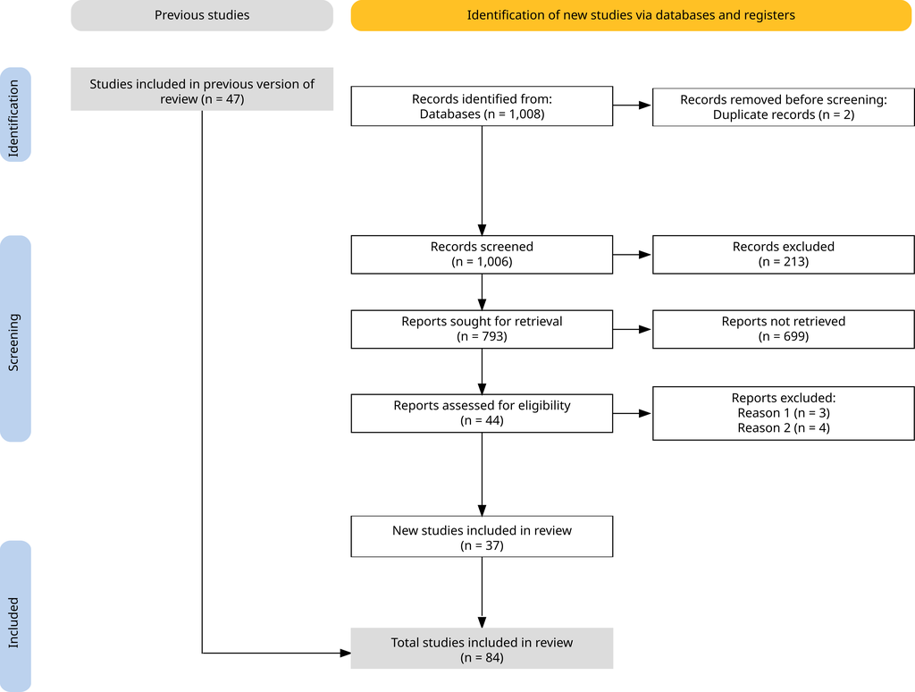

Figure 1: Review process from source selection to analysis. Inspired by the PRISMA 2020 flow diagram Haddaway et al. (2022). Reason 1 = Theory or review paper; Reason 2 = Does not involve machine learning techniques or algorithms. Figure created using *PRIMA2020 R* package and *Inkscape*.

## 2.2 Data collection

| **Feature** | **Number of categories** |
| --- | --- |
| Year | 16 |
| Model | 36 |
| Best model | 13 |
| Family | 8 |
| Subfield | 5 |
| Input data | 4 |
| Evaluation | 3 |
| Result | 5 |
| Pre-training | 4 |
| Country of study area | - |
| Size of the study area | - |
| Size of structures | 5 |
| Data availability | 3 |
| Code availability | 2 |

Table 1: The fourteen features collected systematically from the review along with how many categories they were comprised of.

$$(4)~F1~score = 2\cdot\frac{recall \cdot precision}{recall + precision}$$
Equation 4: F1 score.

**Code for preparing the data**

```r
# 00 Preparation ###############################################################

# 0.1 Folder check =============================================================
getwd()

# Clean up workspace
rm(list = ls(all.names = TRUE))

# 0.2 Load packages ============================================================
install.packages("pacman")
library(pacman) # Easier way of loading packages
pacman::p_load(dplyr, readr, stringr, tidyr, treemap, knitr, kableExtra, sf, rnaturalearth,
               ggplot2, readxl, patchwork, lubridate) # Specify required packages and download it if needed

# 0.3 Show session infos =======================================================
sessionInfo()
```

# 3 Results

From the 84 records analysed, 15 addressed APM approaches and 69 focused on ASD techniques (Figure 2). One study applied two distinct ASD methods, and another used two different APM approaches; these were therefore counted as separate study cases (Agapiou et al., 2021; Li et al., 2024). A clear trend is visible from 2018 onwards, with at least one publication per year in each application area. This pattern intensified after 2020, with around 75% of all papers (*n* = 62) published in 2021 or later. The rapid growth of machine learning applications in archaeology since 2018, and particularly from 2020 and 2021, has also been noted by Bickler (2021), Eleftheriadou et al. (2025, fig. 1), and in our previous work (Bellat et al., 2025, fig. 2).

**Code for figure 2**

```r
# 01 Figure 2, year of publication of the papers ###############################

# 1.1 Prepare the data =========================================================
asd <- read_excel("../data/raw_data/Statistics_papers.xlsx", sheet = "Final_results_ASD")
apm <- read_excel("../data/raw_data/Statistics_papers.xlsx", sheet = "Final_results_APMs")

# Remove Theory (Reason 1) and not ML (Reason 2) papers
asd <- asd[!asd$Results %in%  c("Reason 1", "Reason 2"), ]

# Remove the duplicate study case from Agapiou et al. 2021 and Li et al. 2024
asd.single <- asd[!asd$Name %in%  "Agapiou et al. 2021-2", ]
apm.single <- apm[!apm$Name %in%  "Li et al. 2024-2", ]

# 1.2 Format the data ==========================================
asd_table <- table(asd.single$Year)
apm_table <- table(apm.single$Year)

asd_df <- as.data.frame(asd_table)
apm_df <- as.data.frame(apm_table)

colnames(asd_df) <- c("year", "Freq")
colnames(apm_df) <- c("year", "Freq")

asd_df$year <- as.numeric(as.character(asd_df$year))
apm_df$year <- as.numeric(as.character(apm_df$year))

asd_df$type <- "ASD"
apm_df$type <- "APM"

combined_df <- rbind(asd_df, apm_df)

# Create a full sequence
all_years <- min(combined_df$year):max(combined_df$year)
complete_df <- data.frame(
  year = rep(all_years, 2),
  type = rep(c("ASD", "APM"), each = length(all_years))
)

# Join both df
df_final <- left_join(complete_df, combined_df, by = c("year", "type"))

# Remove NA by 0
df_final[is.na(df_final$Freq), "Freq"] <- 0

# Filter the APMs data before 2015
df_final_filtered <- df_final
df_final_filtered[df_final_filtered$type == "APM" & df_final_filtered$year < 2015, "Freq"] <- NA

# 1.3 Create the plot ==========================================================
plot <- ggplot(df_final_filtered, aes(x = year, y = Freq, color = type)) +
  geom_rect(xmin = 2021, xmax = 2024, ymin = -Inf, ymax = Inf,
            fill = "lightblue", alpha = 0.03, inherit.aes = FALSE) +
  coord_cartesian(xlim = c(min(df_final$year), max(df_final$year) + 1),
                  ylim = c(0, 30)) +
  geom_line(data = subset(df_final_filtered, type == "ASD"),  linewidth = 1.5) +
  geom_line(data = subset(df_final_filtered, type == "APM"),  linewidth = 0.75) +
  geom_point(data = subset(df_final_filtered, type == "ASD" & Freq > 0),
             shape = 21, color = "#69b3a2", fill = "white", size = 4.5, stroke = 1) +
  geom_point(data = subset(df_final_filtered, type == "APM" & Freq > 0),
             shape = 19, color = "#ff7f0e", size = 3) +
  geom_text(aes(label = ifelse(Freq > 0 & type == "ASD" &
                                 year != 2024, round(Freq, 2), "")),
            vjust = -1.2, hjust = 1, color = "black") +
  geom_text(aes(label = ifelse(Freq > 0 & type == "ASD" & year == 2024, round(Freq, 2), "")),
            vjust = -0.95, hjust = -0.2, color = "black") +
  geom_text(aes(label = ifelse(Freq > 0 & type == "APM" & year != 2015, round(Freq, 2), "")),
            vjust = 1.75, hjust = 0, color = "black") +
  geom_text(aes(label = ifelse(Freq > 0 & type == "APM" & year == 2015, round(Freq, 2), "")),
            vjust = -0.95, hjust = 1, color = "black") +
  labs(x = "Years",
       y = paste0("Number of publications (ASD: n = ", sum(asd_df$Freq),
                  ", APM: n = ", sum(apm_df$Freq), ")"),
       color = "Type") +
  scale_x_continuous(breaks = seq(min(df_final$year), max(df_final$year), by = 2)) +
  scale_color_manual(values = c("ASD" = "#69b3a2", "APM" = "#ff7f0e")) +
  theme_classic() +
  theme(legend.position = "top")
```

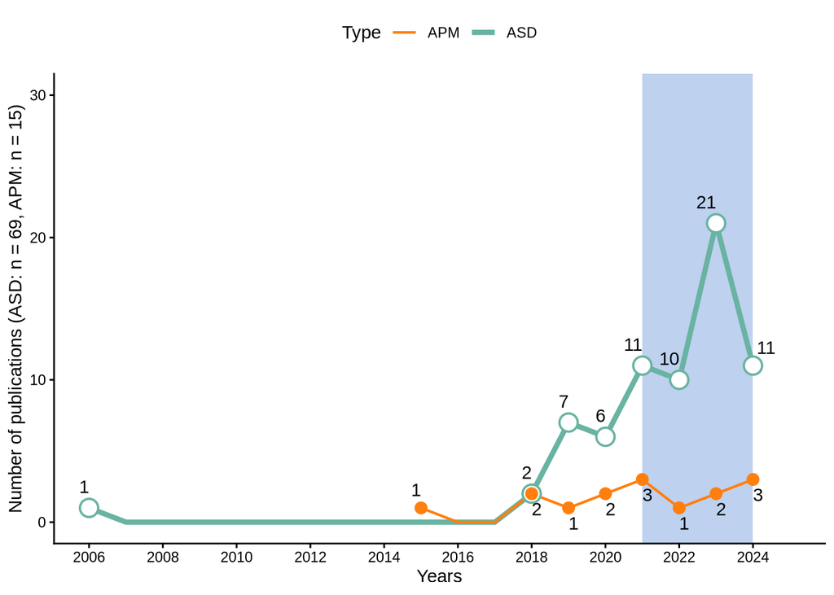

**Code for figure 3**

```r
# 02 Figure 3, tree map ########################################################

# 2.1 Import the data ==========================================================
df <- read_excel("./analysis/data/raw_data/Statistics_papers.xlsx", sheet = "Models statistics")
df <- df[-109,-c(6:10)]
df <- df[df[3] !=0,] # Remove models with no occurences

# 2.2 Format the data ==========================================================
df_counted <- df[,c(1:5)]
names(df_counted) <- c("description", "model", "value", "value.best", "family")
df_counted$family[df_counted$family == "N/A"] <- "Statistics"

# 2.2 Create and export the graph  =============================================
png("./analysis/figures/Fig.3/Fig.3_raw.png", width = 1200, height = 1000)
pdf("./analysis/figures/Fig.3/Fig.3_raw.pdf", width = 12, height = 10)
par(mar = c(0, 0, 0, 0))
tm <- treemap(df_counted,
              index = c("family", "model"),
              vSize = "value",
              type = "index",
              fontsize.labels = c(16, 15),  # Masquer les labels de famille
              fontcolor.labels = c("white", "black"),  # Noir sur Pastel1
              bg.labels = 0,
              align.labels = list(c("left", "top"), c("center", "center")),
              title = "",
              palette = "Pastel1",
              border.col = c("black", "white"),
              border.lwds = c(2, 0))
dev.off()
```

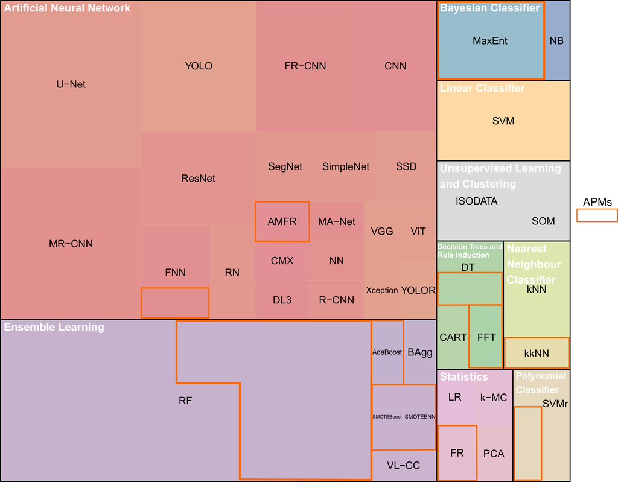

Figure 3: Tree map of the different models used and their related family/group (*n* = 128). APM papers are highlighted by an orange rectangle. Figure generated with *R 4.5.0* and modified with *Inkscape*.

**Code for figure 4**

```r
# 4 Figure 4, family per year of publication ###################################
# 4.1 Prepare the data =========================================================
apm_long <- apm %>%
  separate_rows(Family, sep = ";")

asd_long <- asd %>%
  separate_rows(Family, sep = ";")

combined <- rbind(apm_long[,c(3,6)], asd_long[,c(3,6)])
table <- table(combined)
freq_df <- as.data.frame(table)
colnames(freq_df) <- c("year", "family", "Freq")

# Remove absence of data
freq_df <- freq_df[freq_df$Freq > 0,]
freq_df <- freq_df[freq_df$family != "N/A",]

# Convert the date to number
freq_df$year <- as.numeric(as.character(freq_df$year))

# 4.2 Prepare the plot =========================================================

# Blindfold colors
color <- c('#9F0162', '#009F81', '#FF5AAF', '#00FCCF', '#8400CD', '#008DF9', '#00C2F9', '#FFB2FD')

freq_df <- freq_df %>%
  arrange(year, family) %>%
  mutate(
    cumsum_freq = ave(Freq, year, FUN = cumsum),
    pos = cumsum_freq - 0.5 * Freq)

# print(freq_df)

# 4.3 The plot =================================================================
plot<- ggplot(freq_df, aes(x = year, y = Freq, fill = reorder(family, -as.numeric(family)))) +
  geom_bar(stat = "identity", colour = "white", width = 0.9) +
  geom_text(aes(y = pos, label = ifelse(Freq > 1, Freq, "")),
            color = "white",
            size = 4) +
  scale_fill_manual(values = color,
                    labels = c(
                      "Unsupervised Learning and Clustering"  = "Unsupervised Learning \nand Clustering",
                      "Nearest Neighbour Classifier"  = "Nearest Neighbour \nClassifier",
                      "Artificial Neural Network"  = "Artificial Neural \nNetwork",
                      "Decision Trees and Rule Induction" = "Decision Trees \nand Rule Induction")
  )+
  labs(
    x = "Year",
    y = paste0("Number of observations (n = ", sum(freq_df$Freq), ")"),
    fill = "Architectures \ncategories"
  ) +
  coord_cartesian(xlim = c(2006, 2024), ylim = c(0, 36)) +
  theme_bw() +
  theme(
    legend.position = "bottom",
    legend.box = "vertical",
    legend.margin = margin(),
    legend.text = element_text(size = 9),
    legend.title = element_text(size = 11, face = "bold"),
    axis.text.y = element_text(size = 11),
    axis.title.y = element_text(size = 11, face = "bold"),
    axis.text.x = element_text(size = 11),
    axis.title.x = element_text(size = 11, face = "bold"))

# Plot
plot

ggsave("./analysis/figures/Fig.4/Fig.4_raw.png", plot = plot, width = 9, height = 6, units = "in", dpi = 600)
ggsave("./analysis/figures/Fig.4/Fig.4_raw.pdf", plot = plot, width = 9, height = 6, units = "in")
```

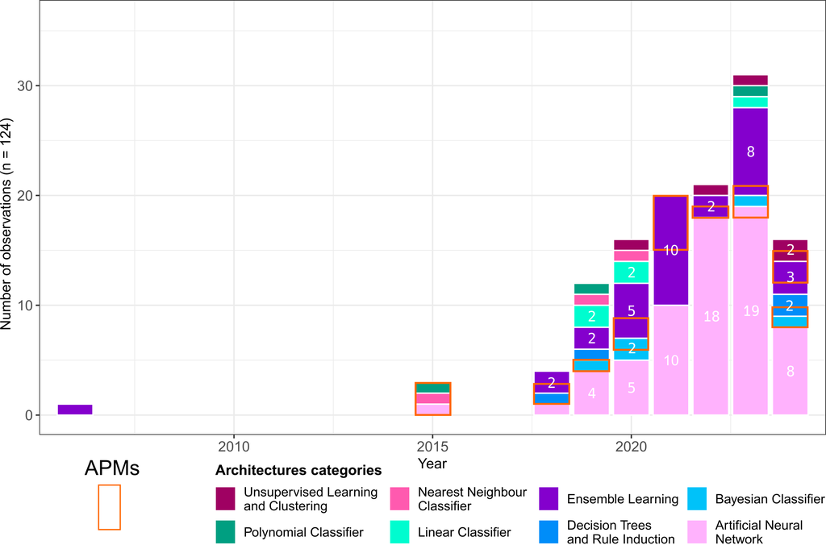

Figure 4: Bar plot of the number of each use of a model family/group per year (*n* = 124). APM papers are highlighted by an orange rectangle. Figure generated with *R 4.5.0* and modified with *Inkscape*.

We also examined model performance scores by plotting precision against recall for ASD models, including F1-score and accuracy when available (Figure 6). The median F1-score was 0.76, while the median accuracy reached 0.86. Precision tended to be slightly higher (median = 0.86) than recall (median = 0.74). However, a subset of studies reported very low precision, which reduced the mean values of both precision and recall to 0.74.

**Code for figure 5**

```r
# 05 Figure 5, results and metrics #############################################

# 5.1 Import the data ==========================================================
metrics <- read_excel(".analysis/data/raw_data/Statistics_papers.xlsx", sheet = "Metrics_full")

# 5.2 Prepare the data =========================================================
metrics <- as.data.frame(metrics)
metrics_df <- data.frame(
  eval_metrics = character(),
  study_id    = character(),
  score       = numeric(),
  type        = character(),
  stringsAsFactors = FALSE
)
metrics_df[1,] <- c("","",0,"")

for (i in 1:nrow(metrics)) {
  metric <- metrics[i,c(5:23)]
  metric <- metric[, colSums(is.na(metric)) == 0, drop = FALSE]
  metric <- round(metric, digit = 2)
  if (ncol(metric) == 0) {
    NA
  } else if (ncol(metric) == 1) {
    x <- as.data.frame(c(colnames(metric), metrics[i, 2], metric, metrics[i, 4]))
    colnames(x) <- colnames(metrics_df)
    metrics_df <- rbind(metrics_df, x)
  } else {
    for (j in 1:ncol(metric)) {
      x <- c(colnames(metric[j]), metrics[i, 2], metric[,j], metrics[i, 4])
      metrics_df <- rbind(metrics_df, x)
    }
  }
}

metrics_df <- metrics_df[-1,]

# 5.3 Prepare the plot =========================================================
metric_counts <- table(metrics_df$eval_metric)
sorted_metrics <- names(sort(metric_counts, decreasing = FALSE))

study_counts <- table(metrics_df$study_id)
sorted_studies <- names(sort(study_counts, decreasing = TRUE))

metrics_df$present <- 1

all_combinations <- expand.grid(
    eval_metrics = sorted_metrics,
    study_id = sorted_studies,
    stringsAsFactors = FALSE)


plot_data <- merge(all_combinations, metrics_df,
                     by = c("eval_metrics", "study_id"), all.x = TRUE)

plot_data$present[is.na(plot_data$present)] <- 0

study_counts_df <- data.frame(
    study_id = names(study_counts),
    metric_count = as.numeric(study_counts))

plot_data <- merge(plot_data, study_counts_df, by = "study_id")

plot_data <- plot_data %>%
  select(-type) %>%
  left_join(metrics %>% select(Name, Task) %>% distinct(),
            by = c("study_id" = "Name"))

plot_data$eval_metrics <- factor(plot_data$eval_metrics, levels = sorted_metrics)
plot_data$study_id <- factor(plot_data$study_id, levels = sorted_studies)
plot_data<- plot_data[order(plot_data$metric_count, decreasing = TRUE), ]


# 5.4 Create the plot ==========================================================
plot <- ggplot(plot_data, aes(x = study_id, y = eval_metrics))+
    geom_tile(aes(fill = ifelse(present == 1, metric_count, NA)),
              color = "gray", size = 0.3) +
  geom_text(aes(
    label = ifelse(
      present == 1 & !is.na(score) & metric_count <= 3,
      score, "")),
    color = "black", size = 2, fontface = "bold") +
  geom_text(aes(
    label = ifelse(
      present == 1 & !is.na(score) & metric_count > 3,
      score, "")),
    color = "white", size = 2, fontface = "bold") +
    scale_fill_gradient(low = "#DEEBF7", high = "#08519C",
                        name = "Metric\nCount",
                        na.value = "transparent",
                        breaks = c(2, 3, 4, 5, 6),
                        labels = c("2", "3", "4", "5", "6+")) +
    labs(
      x = "Case Studies",
      y = "Evaluation Metrics"
    ) +
    theme_minimal() +
    theme(
      axis.text.x = element_text(angle = 45, hjust = 1, size = 6),
      axis.text.y = element_text(size = 6),
      legend.title = element_text(size = 8),
      legend.text = element_text(size = 8),
      axis.title.x = element_text(size = 8),
      axis.title.y = element_text(size = 8),
      panel.grid = element_blank()
)
```

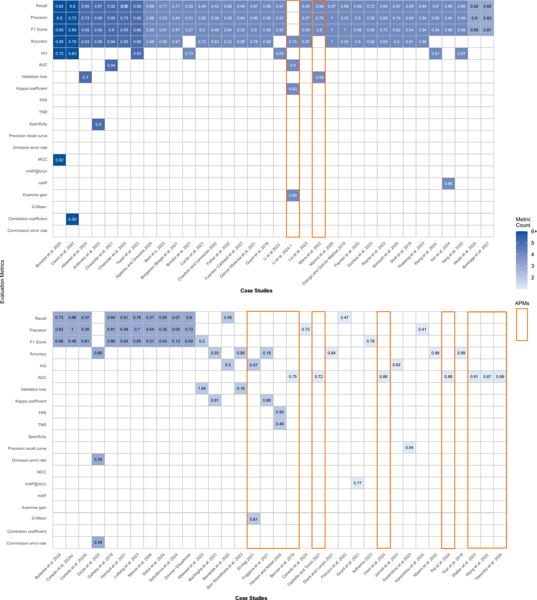

Figure 5: Number of metrics and metrics scores presented in the reviewed papers (*n* = 69). Some papers did not present any metrics. The different metrics are represented on the left, and the case study citation note is at the bottom. The blue gradient indicates the number of metrics used for one case study, with a minimum of 1 (pale blue) and a maximum of 6 (strong blue). APM papers are highlighted by an orange rectangle. Figure generated with *R 4.5.0* and modified with *Inkscape*, inspired by Eleftheriadou et al. (2025).

**Code for figure 6**

```r
# 06 Figure 5, scatterplot  ####################################################

# 6.1 Prepare the data =========================================================

scatter_df <- metrics[metrics$Task == "Automatic Structure Detection",]
scatter_df <- scatter_df[!is.na(scatter_df$`F1 Score`),]
scatter_df$ID <- gsub("ID0", "", scatter_df$ID)
scatter_df$ID <- gsub("ID", "", scatter_df$ID)

# 6.2 Plot the data ============================================================

plot <- ggplot(scatter_df , aes(x = Recall, y = Precision, label = ID)) +
  geom_point(aes(size = `F1 Score`, color = Accuracy)) +
  geom_text(size = 2.5, vjust = -2, hjust = 1) +
  scale_size_continuous(range = c(3, 8)) +
  scale_color_viridis_c(option = "viridis", end = 0.99) +
  xlim(0, 1) + ylim(0, 1) +
  labs(
    x = "Recall",
    y = "Precision",
    color = "Accuracy",
    size  = "F1-score"
  ) +
  theme_minimal()
```

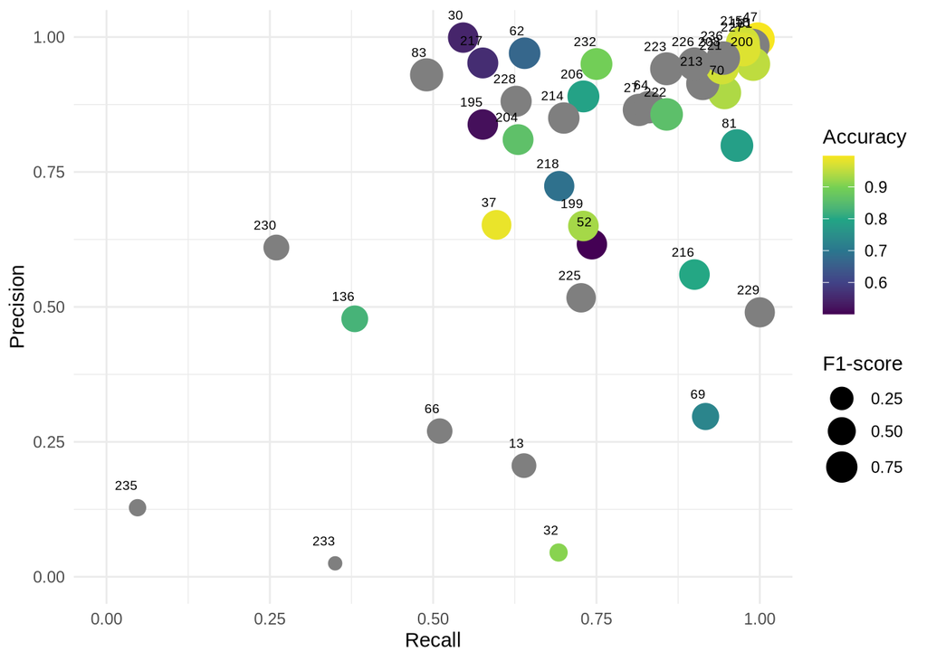

Figure 6: Scatter plot of the recall and precision scores for the ASD records (*n* = 45), numbered according to the ID number of the study in our table. F1-score is represented by the area of the point, and accuracy is shown with a gradient colour when available. Figure generated with *R 4.5.0* and modified with *Inkscape*.

**Code for figure 7**

```r
# 07 Figure 7, Country of the study area #######################################

# 7.1 Prepare the data  ========================================================
col_name <- names(apm)[19]
apm_long <- apm %>%
  separate_rows(col_name, sep = ";")

asd_long <- asd %>%
  separate_rows(col_name, sep = ";")

combined <- rbind(apm_long[,19], asd_long[,21])
table <- table(combined)
freq_df <- as.data.frame(table)
colnames(freq_df) <- c("name", "value")

world <- ne_countries(scale = "medium", returnclass = "sf")

# 7.2 Formate the names  =======================================================

replace <- c("USA" = "United States of America",
             "American Sāmoa" = "American Samoa",
             "Maurice" = "Mauritius",
             "Republic of the Marshall Islands" = "Marshall Is.")

freq_df  <- freq_df  %>%
  mutate(name = recode(name, !!!replace))

freq_df$name[freq_df$name == ""] <- NA

freq_df <- na.omit(freq_df)

map_data <- world %>%
  left_join(freq_df, by = "name")

plot <- ggplot(map_data) +
  geom_sf(aes(fill = value)) +
  labs(fill = "Number of \nstudies") +
  scale_fill_gradient(
    low = "#deebf7",
    high = "#08306b",
    na.value = "grey95"
  ) +
  coord_sf(crs = "+proj=robin") +
  theme_minimal() +
  theme(axis.text.x = element_blank())
```

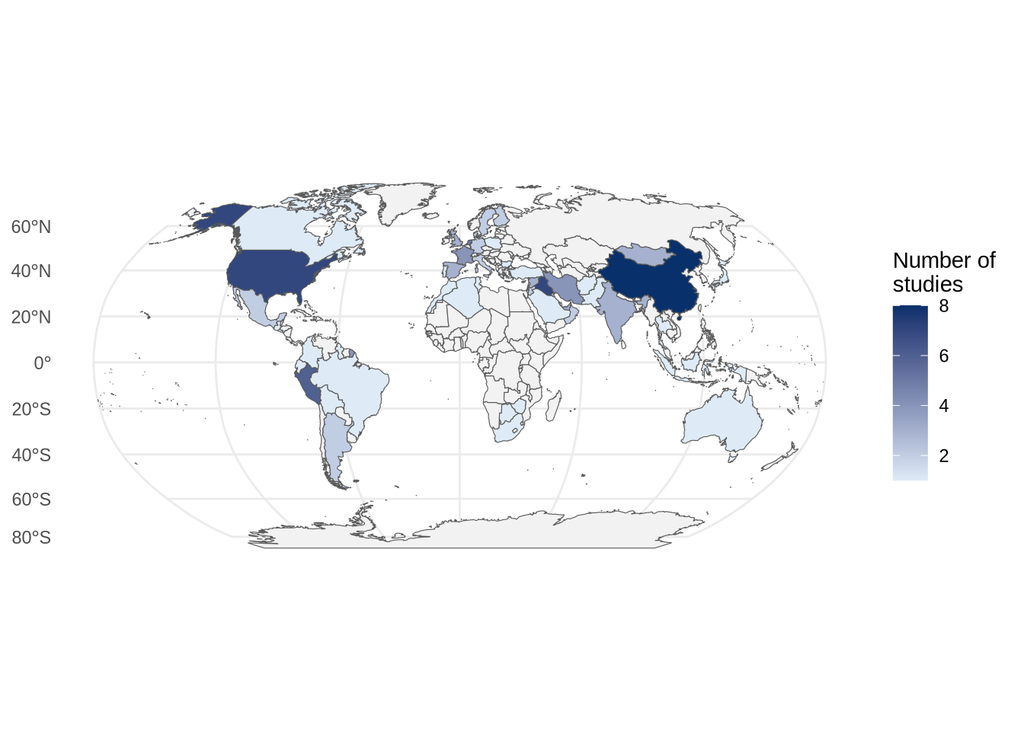

Figure 7: Map of the countries where the studies were conducted (*n* = 115). Figure generated with *R 4.5.0*.

**Code for figure 8**

```r
# 08 Figure 8, Surface of the AOI and structure ################################

# 8.1 Prepare the data for the first figure ====================================

col_name <- names(apm)[21]
apm_long <- apm %>%
  separate_rows(col_name, sep = ";")
apm_long$type <- "apm"

asd_long <- asd %>%
  separate_rows(col_name, sep = ";")
asd_long$type <- "asd"

combined <- rbind(apm_long[,c(21,24)], asd_long[,c(23,27)])

combined[[1]] <- str_replace_all(combined[[1]],
                              pattern = c("\\~"="", " "="", ","="", "km2"=""))


text_clean1 <- str_replace_all(apm_long[[21]],
                              pattern = c("\\~"="", " "="", ","="", "km2"=""))
text_clean1 <- na.omit(as.numeric(text_clean1))

text_clean2 <- str_replace_all(asd_long[[23]],
                               pattern = c("\\~"="", " "="", ","="", "km2"=""))
text_clean2 <- na.omit(as.numeric(text_clean2))

df <- data.frame(combined)
df <- na.omit(df)
df[[1]] <- as.numeric(df[[1]])

df <- df %>%
  mutate(pct = 1 / nrow(df))

colnames(df) <- c("size_num", "type", "pct")

# 8.2 First figure plot ========================================================

gg1 <- ggplot(df, aes(x = size_num, weight = pct, fill = type)) +
  geom_density(position = "stack", color = "NA", alpha = 0.6) +
  scale_x_continuous(trans='log10') +
  scale_fill_manual(values = c("apm" = "#440154",
                                 "asd" = "#31688e")) +
  labs(
    x = "Size of the study (log scale km²)",
    y = "Proportion of studies") +
  theme_minimal() +
  theme(legend.position="none",
        panel.grid.minor.x = element_blank(),
        panel.grid.minor.y = element_blank()) +
  annotate("text", x = 0, y = 0.42, label = "A", fontface = "bold", size = 9, hjust = -0.2, vjust = 0.5) +
  annotate("text", x = 200, y = 0.25, label = "APMs", size = 5, hjust = -0.2, vjust = 0.5) +
  annotate("text", x = 10, y = 0.05, label = "ASDs", size = 5, hjust = -0.2, vjust = 0.5)

# 8.3 Prepare the data for the second figure ===================================

col_name <- names(asd)[24]
asd_long <- asd %>%
  separate_rows(col_name, sep = ", ")

size_num <- as.factor(na.omit(asd_long[[24]]))
size_num <- factor(size_num, levels=c('Layer level (< 5 m)', 'Small (5 > 50 m)', 'Medium (50 > 200 m)',
                                      'Large (200 > 500 m)', 'Site level (> 500m)'))
df <- as.data.frame(size_num)

# 8.4 Second figure plot =======================================================

gg2 <- ggplot(df, aes(x = size_num, fill = size_num)) +
  geom_bar() +
  labs(
    x = "",
    y = "Number of studies") +
  scale_fill_viridis_d() +
  theme_classic() +
  scale_y_continuous(limits = c(0, NA), expand = expansion(mult = c(0, 0.05))) +
  theme(legend.position="none",
        axis.line.x =element_blank(),
        axis.ticks.x=element_blank()) +
  annotate("text", x = 0.5, y = 40, label = "B", fontface = "bold", size = 9, hjust = -0.2, vjust = 0.5) +
  theme(axis.text.x = element_text(angle = 45, vjust = 0.9, hjust =1))

# 8.5 Combined figure ==========================================================

plot <- gg1|gg2
```

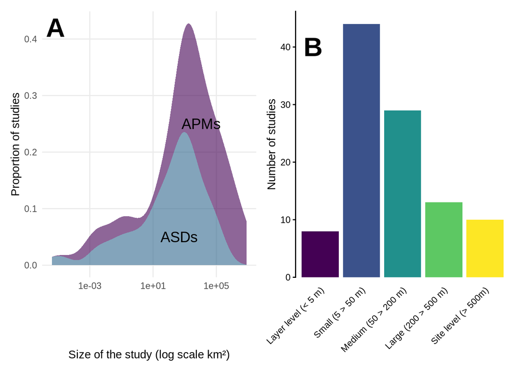

Figure 8: **A**: Density plot of the area of interest size - transformed in log10 - for both APMs and ASDs records (*n* = 91). **B**: Bar plot of the size of structures of the ASDs records (*n* = 104). Figure generated with *R 4.5.0*.

# 4 Discussion

## 4.1 Common elements

From a theoretical perspective, both archaeological predictive models and archaeological structure detection share a common conceptual background. At their core lies the notion of site probability (Gillies et al., 2016; Hodder and Orton, 1976; Willey, 1953), rooted in the fundamental archaeological question of why “populations located sites where they did” (Kvamme, 2020, p. 213). Both approaches address this question by attempting to predict site locations. Judge and Lynne defined prediction as “*the ability to foretell on the basis of observation, experience, or scientific reason*” (Judge and Sebastian, 1988b, p. 2). This predictive dimension was explicitly present in the early stages of APMs (Verhagen and Whitley, 2012), and is even reflected in their name, but it is less immediately visible in the terminology of ASD. Nevertheless, one of the earliest works to apply predictive modelling for archaeological structure detection in remote sensing imagery - Menze et al. (2006) on Syrian tells - explicitly framed the task as the need for “*a comprehensive and accurate listing of these sites*” effectively operationalising presence/absence prediction in a way analogous to APMs.

Another key similarity between APMs and ASDs lies in their reliance on remote sensing data, whether derived from UAVs (*e.g.*, Monna et al., 2020; Orengo and Garcia-Molsosa, 2019; Sakai et al., 2024), aircraft (*e.g.*, Bonhage et al., 2021; Guyot et al., 2021; Lidberg et al., 2024), or satellites (*e.g.*, Caspari and Crespo, 2019; Castiello and Tonini, 2021; Karamitrou et al., 2023). The rise of both applications is closely tied to the broader expansion of remote sensing in archaeology (Argyrou and Agapiou, 2022), itself driven by the rapid increase in Earth observation satellites since 2015 (Figure 9). This growth has also been fueled by greater accessibility to satellite and LiDAR datasets, as well as by major improvements in image resolution, particularly from modern airborne laser scanning (ALS) platforms (0.5 - 1 m resolution) and UAVs. Future developments in remote sensing are likely to further enhance archaeological applications, not only through sensor advances but also through computational methods such as super-resolution techniques (Liu et al., 2025; Wang et al., 2022).

**Code for figure 9**

```r
# 09 Figure 9, Remote sensing publication ######################################

# 9.1 Prepare the data for dimension ===========================================

# For the Dimension website (visited on the 20/08/2025)
# Inclusion criteria "remote sensing" keyword; 43 (History, Heritage and Archaeology) category
# Years 2000 to 2024

number <- c(176,192,188,181,205,213,246,322,345,375,431,
            585,770,854,926,850,1109,1092,1204,1180,1480,1597,1758,1804,1949)
years <- seq(2000, 2024, by = 1)
df_dimension <- data.frame(year = years, Freq = number)

# 9.2 Prepare the data for web of science ======================================
# For the Web of Science website (visited on the 20/08/2025)
# Inclusion criteria "remote sensing" keyword; Arcaheology Web of Science category
# Years 2000 to 2024

number <- c(6,4,2,5,2,9,10,14,13,32,18,61,22,22,25,21,61,64,147,243,88,73,128,753,78)
years <- seq(2000, 2024, by = 1)
df_web <- data.frame(year = years, Freq = number)

# 9.3 Prepare the data for UCS Satellite Database ==============================
# Visited on the 20/08/2025 at https://test.ucsaction.org/resources/satellite-database
sat <- read_excel("../data/raw_data/UCS-Satellite-Database 5-1-2023.xlsx")

# Select only satellites for earh observation non military
sat <- sat[sat$Purpose == "Earth Observation",]
sat <- sat[sat$Users != "Military",]
number <- sat$`Date of Launch`
number <- na.omit(number)
number <- as.numeric(number)
number <-  as.Date(number, origin = "1899-12-30")
year <- year(number)

# Select only satellites lunched after 2000
year <- year[year > 1999]
df_sat <- as.data.frame(table(year))
df_sat$year <- as.character(df_sat$year)
df_sat$year <- as.numeric(df_sat$year)

# 9.4 Plot the data ============================================================

plot1 <- ggplot(df_dimension, aes(x = year, y = Freq)) +
  coord_cartesian(xlim = c(min(years), max(years) + 1),
                  ylim = c(0, 2000)) +
  geom_line(color = "#69b3a2", linewidth = 1) +
  geom_point(shape = 19, color = "#69b3a2", size = 3) +
  annotate("text", x = 2000, y = 2000, label = "A", fontface = "bold", size = 11, hjust = 0.5, vjust = 1.1) +
  labs(y = "Number of records in Dimension",
       x = "Year") +
  theme_minimal() +
  theme(panel.grid.major.x = element_blank(),
        panel.grid.minor.x = element_blank())

plot2 <- ggplot(df_web, aes(x = year, y = Freq)) +
  coord_cartesian(xlim = c(min(years), max(years) + 1),
                  ylim = c(0, 800)) +
  annotate("text", x = 2000, y = 800, label = "B", fontface = "bold", size = 11, hjust = 0.5, vjust = 1.1) +
  geom_line(color = "#69b3a2", linewidth = 1) +
  geom_point(shape = 19, color = "#69b3a2", size = 3) +
  labs(y = "Number of records Web of Science",
       x = "Year") +
  theme_minimal() +
  theme(panel.grid.major.x = element_blank(),
        panel.grid.minor.x = element_blank())

plot3 <- ggplot(df_sat, aes(x = year, y = Freq)) +
  coord_cartesian(xlim = c(min(years), max(years) + 1),
                  ylim = c(0, 150)) +
  annotate("text", x = 2000, y = 150, label = "C", fontface = "bold", size = 11, hjust = 0.5, vjust = 1.3) +
  geom_line(color = "#69b3a2", linewidth = 1) +
  geom_point(shape = 19, color = "#69b3a2", size = 3) +
  labs(y = "Number of earth observation satellites \nlunched (UCS Satellite Database)",
       x = "Year") +
  theme_minimal() +
  theme(panel.grid.major.x = element_blank(),
        panel.grid.minor.x = element_blank())

plot <- (plot1 | plot2) / plot3
```

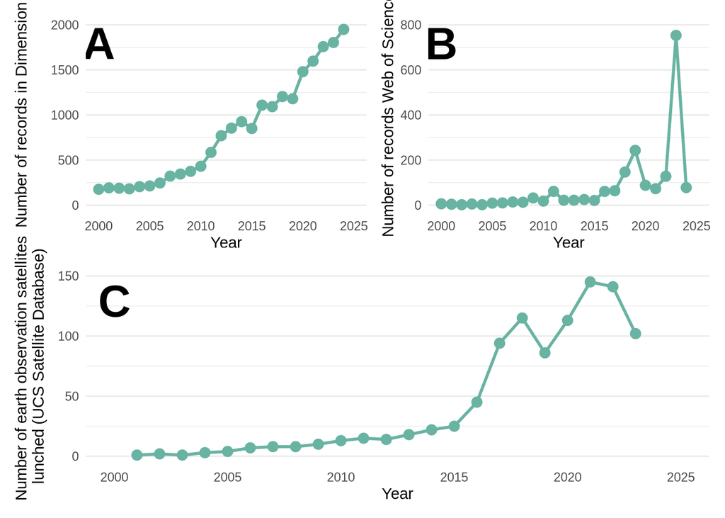

Figure 9: **A**: Number of records in the archaeological field mentioning remote sensing in the Dimension database. **B**: Number of records in the archaeological field mentioning remote sensing in the Web of Science database. **C**: Number of satellites dedicated to earth observation launched per year, according to the USC database, we did not take military satellites into account. Figure generated with *R 4.5.0*.

Despite differences in the types of models employed in APMs and ASDs, both fields show a strong reliance on the RF algorithm. In ASD tasks, RF accounts for nearly 20% of applications (*n* = 18), while in APMs it represents 41% (*n* = 10). The prominence of RF in archaeological machine learning is unsurprising: the method is relatively straightforward to implement and can be applied flexibly to both classification and prediction problems (Breiman, 2001).

Another common theme is the broadly worldwide representation of both APM and ASD study cases (Figure 7). Concerning these trends, the underrepresentation of African case studies likely reflects limited access to funding and lack of large-scale remote sensing datasets are likely to also contribute to this imbalance. In the post-Soviet sphere, lower representation might come from a historical tendency toward relative scientific isolation within Russia and some affiliated countries. Between 1993 and 2017, Russia accounted for only approximately 0.33% of global publications in humanities, on average (Gilyarevskii et al., 2019, Table 3). This structural separation from mainstream international research networks has probably intensified following the Russian aggressions against Ukraine from 2014 and 2022 onwards, further limiting scientific collaboration and visibility (Jack, 2024). Conversely, the comparatively high representation of ASD applications in Iraq and Peru may be explained by favourable environmental and archaeological conditions. Large parts of Iraq and neighbouring regions of the Arabian Peninsula are characterised by relatively flat topography and sparse vegetation cover, conditions that enhance the performance of satellite-based remote sensing (Casana, 2020). In addition, characteristic settlement forms such as tells - artificial mounds formed by long-term occupation - are particularly well suited to aerial and satellite detection methods (Menze et al., 2006), though the centuries-old interest in the region for its well-renowned history and archaeology is undoubtedly a contributing factor. Comparable environmental advantages are also found in parts of coastal and arid Peru, where low vegetation density and clear surface visibility support remote sensing approaches (Sakai et al., 2024; Sakai et al., 2023; Zimmer-Dauphinee et al., 2024).

## 4.2 Differences in approaches

While APMs and ASDs share several similarities, important differences explain why they have followed distinct research trajectories. From a theoretical standpoint, APMs benefit from a more established background built over more than 40 years of practice (Judge and Sebastian, 1988a; Kvamme, 2020). They have also faced criticism, particularly for their perceived deterministic nature (Kamermans et al., 2004; Kvamme, 2006), reflecting their strong roots in ecological science (Yaworsky et al., 2024). By contrast, ASDs have been less subject to such criticism, as they are more data-driven and object-focused. Their main limitations concern their ability to connect with broader archaeological questions and engage a wider audience (Davis, 2021, 2020, 2019). However, the past five years have seen growing interest in ASDs (Bennett et al., 2025). The OpenAI to Z Challenge is one example of bridging a niche method with public engagement, aiming to locate archaeological sites in the Amazon using large language models and computer vision tools with OpenAI o3/o4 mini and GPT-4.1 (https://openai.com/openai-to-z-challenge).

Differences are also evident in the use of machine learning methods. ASD studies frequently employ artificial neural networks (ANNs; *n* = 57), particularly U-Net (*e.g.*, Anttiroiko et al., 2023; Bundzel et al., 2020; Garcia-Molsosa et al., 2021), convolutional neural networks (CNNs Gallwey et al., 2019; Ikäheimo, 2023; Soroush et al., 2020), and their region-based or mask-based variants (*e.g.*, Bonhage et al., 2021; Quintus et al., 2023; Verschoof-van der Vaart and Lambers, 2019). In contrast, our review found only two APM studies using ANNs (Oonk and Spijker, 2015; Wang et al., 2023). Bayesian classifiers also show divergent use: MaxEnt appears exclusively in APMs (*e.g.*, Benner et al., 2019; Imen et al., 2024; Wang et al., 2023), given its suitability for handling pseudo-absence data (Yaworsky et al., 2020).

**Code for figure 10**

```r
# 10 Figure 10, covariates selection ############################################

# 10.1 Prepare the data =========================================================

cov <- data.frame(name = apm$Name, nb.cov = apm$`Nb. Cov.`, cov.sel = apm$`Cov. Selec.`)
cov <- na.omit(cov)
cov$cov.sel <- c(8,2,8,21,10,25,6,27,65,8,16,16,7,12)
cov$cov.type <- c("PCA", NA, NA,"Human", "PCA", NA, "Human", NA,
              NA, "VIF/auto-correl", NA, NA, NA, NA)
cov_long <- cov %>%
  pivot_longer(cols = c("nb.cov", "cov.sel"),
               names_to = "metric",
               values_to = "value") %>%
  mutate(metric = case_when(
    metric == "nb.cov" ~ "Nb Coverage",
    metric == "cov.sel" ~ "Coverage Selected",
    TRUE ~ metric
  ))


# 10.2 Plot the data ============================================================

plot <- ggplot(cov, aes(x = name)) +
  geom_col(aes(y = nb.cov),
           fill = "lightpink", width = 0.8) +
  geom_col(aes(y = cov.sel, fill = cov.type),
           width = 0.8) +
  labs(
    y = "Number of covariates",
    x = "",
    fill = "Covariates selection \ntype (if any)") +
  theme_minimal() +
  theme(
    axis.text.x = element_text(angle = 45, hjust = 1),
    legend.position = "bottom",
    panel.grid.major.x = element_blank(),
    panel.grid.minor.x = element_blank()
  ) +
  scale_fill_brewer(type = "qual", palette = "Pastel2")
```

[figure not shown]

Figure 10: Number of covariates used in the APMs papers reviewed and the type of feature selection selected (*n* = 14). Figure generated with *R 4.5.0*.

Interpretability also differs markedly. ASD, especially when based on deep learning, is often considered a “black box” because the contribution of individual features is unclear (Bickler, 2021). Recent progress in explainable AI (XAI) has improved transparency, for example, through saliency maps that highlight which areas of an image drive predictions (Barredo Arrieta et al., 2020; Xu et al., 2019; but see, Rudin, 2019). However, XAI remains relatively uncommon in ASD. In contrast, APMs naturally lend themselves to interpretation, as the influence of each covariate can be quantified and visualised (Li et al., 2024).

When examining the size of the AOIs, another difference was a broader spatial extent observed in APM studies (Figure 8A). It can largely be explained by the environmental scope and conceptual framework underlying these models (Kvamme, 2020). Predictive modelling aims to capture landscape-scale patterns, which requires accounting for spatially dispersed and sometimes distant environmental variables. Moreover, APMs frequently rely on survey datasets or institutional records (Castiello and Tonini, 2021; Imen et al., 2024; Miera et al., 2022), which typically cover extensive geographic regions. In contrast, automatic structure detection applications tend to provide detailed analyses of localized phenomena. These studies are often constrained to relatively small regions (Guyot et al., 2018; Sakai et al., 2023; Trier et al., 2018) or rely on high-resolution UAV imagery covering individual fields or restricted surfaces (Monna et al., 2020; Orengo and Garcia-Molsosa, 2019).

Regarding the size of the detected structures in ASD records, the predominance of features ranging between 5 m and 200 m (Figure 8B) reflects the primary archaeological targets of these studies. Most applications focus on domestic structures (Bundzel et al., 2020; Zimmer-Dauphinee et al., 2024), individual constructions (Davis and Lundin, 2021; Gallwey et al., 2019), or funerary features (Guyot et al., 2018; Trier et al., 2018). Only a limited proportion of studies address large-scale fortifications (Canedo et al., 2024; Stott et al., 2019), collective architectural complexes (Soroush et al., 2020), or entire archaeological sites (Garcia-Molsosa et al., 2021; Menze et al., 2006; Orengo et al., 2020). On the other hand, APM approaches only focus on site-scale prediction and detection.

Finally, APMs generally follow a well-established and relatively lightweight workflow requiring limited computational resources, reflecting their long-standing use in archaeology. By contrast, ASD research is less standardised, employing a wide range of models and metrics (Figure 3; Figure 5; Figure 6). This diversity is unsurprising given its recent and rapidly evolving development, combined with the variety of models used. Over time, ASD workflows may become more structured as the field matures. However, they remain computationally demanding, requiring substantial time and resources despite the accessibility of cloud platforms such as *Google Colab*.

## 4.3 Limitation of the study

Several limitations of our study should be acknowledged. First, our screening strategy (see Section 2.2) involved the review of some articles by a single author, while records from Bellat et al. (2025) were reviewed by two authors. This element might have introduced subjectivity when assessing certain objective criteria (*e.g.*, subfield classification), although the collected items largely consist of fixed categories (Table 1). Our strategy also excluded non-peer-reviewed publications and non-English language records. Inclusion of diverse sources, such as book chapters or conference proceedings, might have altered some results. However, trends observed in non-peer-reviewed materials - as observed by the authors of this publication - were largely consistent with those reported here. Additionally, our decision to report only the highest evaluation scores prevents comparisons across the full range of scores where various models were applied but only the best performing reported, which could have otherwise provided a more nuanced assessment of model performance. Due to concerns about reproducibility and inter-rater reliability, we therefore relied on a single metric per record. Interpretation of archaeological research questions based on model results was consistently guided by the best-performing model.

**Code for table 2**

```r
# 11 Table for the data/code-access ############################################

# 11.1 Table for data ==========================================================
data_table <- rbind(asd.single[,c(2,25)], apm.single[,c(2,22)])
data_df <- as.data.frame(data_table)

data_df <- data_df[data_df[2] != "No",]

colnames(data_df) <- c("name", "Availability")
table_data <- data_df %>%
  group_by(Availability) %>%
  summarise(
    Number = n(),
    References = paste(name, collapse = "; "),
    .groups = "drop"
  )

# 11.2 Table for code ==========================================================
data_table <- rbind(asd.single[,c(2,26)], apm.single[,c(2,23)])
data_df <- as.data.frame(data_table)

data_df <- data_df[data_df[2] == TRUE,]

colnames(data_df) <- c("name", "Availability")
table_code <- data_df %>%
  group_by(Availability) %>%
  summarise(
    Number = n(),
    References = paste(name, collapse = "; "),
    .groups = "drop"
  )

table_final <- rbind(table_data, table_code)
table_final <- as.data.frame(table_final)
```

[output not shown]

Table 2: Available material and code from the reviewed studies (*n* = 84).